# Cytation RT-glo JAB

Darren Tyson

December 22, 2021

```r
library(diprate)
```

## Cell counts extracted using updated `py-seg`

Image segmentation using `py-seg` had to be modified to account for lower spatial resolution of camera in Cytation 5 in HTS core. Monica ran NextFlow processing on data saved in `/vu1file/quaranta2/Cytation`. Files were copied into RT-Glow git repo.

## Load cell count data

```r
d <- read.csv("../data/2021-12-07_JAB002_PC9.1/cellCounts_JAB002.csv", row.names=1)
d <- d[order(d$plate_id,d$well),]
rownames(d) <- NULL
d$pos <- sapply(sapply(d$file_name, function(x) strsplit(x,"_")), "[[", 4)
d$uid <- paste(d$plate_id,d$well,sep="_")

# add up all counts in each well at each timepoint
a <- aggregate(cell_count ~ uid, data=d, FUN=sum)
a$plate_id <- sapply(strsplit(a$uid, "_"), "[[", 1)
a$well <- sapply(strsplit(a$uid, "_"), "[[", 2)
```

## Load plate map and clean

```r
pm <- read.csv("../data/2021-12-07_JAB002_PC9.1/Platemap2-JAB002.csv", skip=1)
pm <- pm[1:16,1:25]
rownames(pm) <- pm[,1]
pm <- pm[,-1]
colnames(pm) <- as.character(1:24)
pm <- apply(pm, c(1,2), function(x) ifelse(x=="NULL",NA, gsub("c","",x)))
pm <- data.frame(seed.dens=matrix(pm, ncol=1))

wellnames <- fixWellName(sapply(LETTERS[1:16], function(x) paste0(x,1:24)))
pm$well <- wellnames[order(as.integer(gsub("[A-P]","",wellnames)))]

# capture positions of nonempty wells
well_i <- which(!is.na(pm$seed.dens))

pm <- pm[!is.na(pm$seed.dens),c("well","seed.dens")]
rownames(pm) <- NULL
```

**NOTE:** Plate was rotated 180deg on first time point: should correct well names of data

```r
rotated_wells <- rev(wellnames)[order(as.integer(gsub("[A-P]","",wellnames)))][well_i]
names(rotated_wells) <- wellnames[order(as.integer(gsub("[A-P]","",wellnames)))][well_i]

a[a$plate_id==1,"well"] <- rotated_wells[a[a$plate_id==1,"well"]]

# fix uids
a$uid <- paste(a$plate_id, a$well, sep="_")
```

**NOTE:** Plate map only shows initial expected seeding densities. All cells are PC9.1

## Apply plate map info to data

```r
a$drug1 <- pm[match(a$well,pm$well),"seed.dens"]
a$drug1.conc <- 0
```

## Pull times from expt directory names

Need to parse times from directory names (first part)  
Copied `getDateTime` function from `2020-12-14_Cytation_analysis.Rmd`

```r
getDateTime <- function(dname)
{
    o <- dname[grepl("[0-9]{6}_*[0-9]{6}",dname)]
    if(all(grepl("[0-9]{12}",o)))
    {
        mytime <- strptime(o, '%y%m%d%H%M%S')
    } else {
        mytime <- paste(sapply(strsplit(o,'_'), '[[', 1),
            sapply(strsplit(o,'_'), '[[', 2), sep='_')
        mytime <- strptime(mytime, '%y%m%d_%H%M%S')
    }
    names(mytime) <- NULL
    return(mytime)
}
```

```r
temp_times <- read.table("../data/2021-12-07_JAB002_PC9.1/expt_dirs.txt")[,1]
# temp_times <- sapply(strsplit(temp_times,"_"), "[[", 1)
temp_times <- lapply(temp_times, getDateTime)
a$image.time <- sapply(temp_times[as.integer(a$plate_id)], as.character)
TxTime <- "2021-12-07 13:00:00"
a$time <- signif(as.numeric(difftime(a$image.time, TxTime, units="hours")),3)
colnames(a)[colnames(a)=="cell_count"] <- "cell.count"

a <- a[order(a$well, a$time),]
```

To facilitate plotGC function call, use `well` as `uid`.

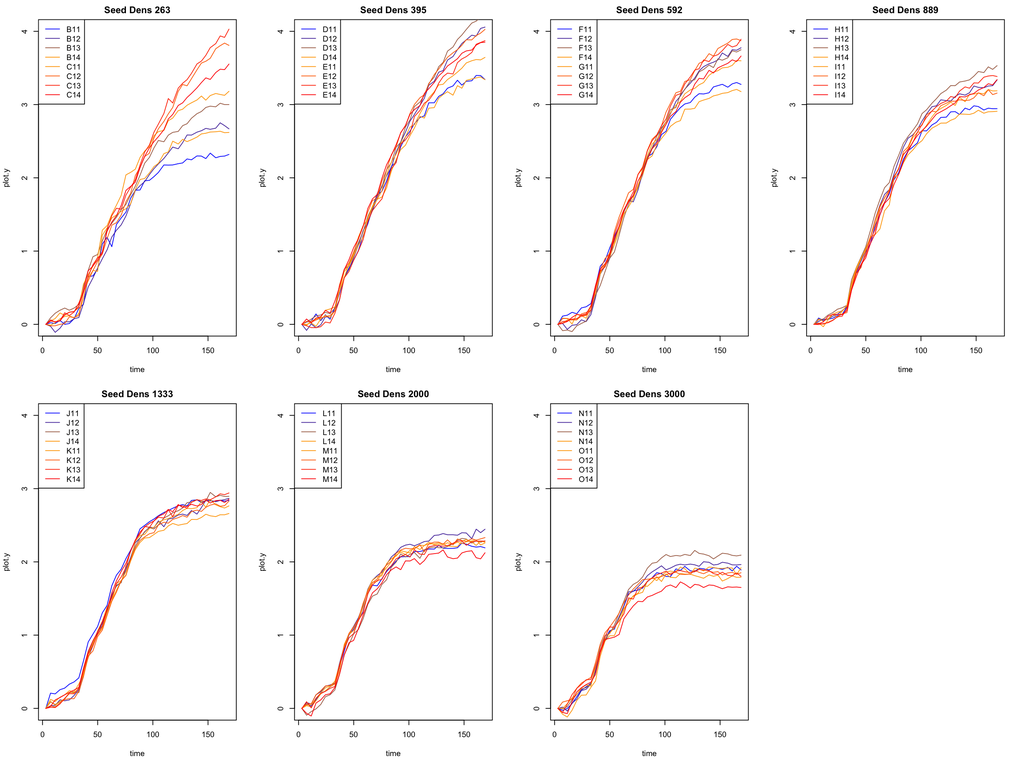

```r
a$uid <- a$well

par(mfrow=c(2,4))
temp <- lapply(unique(a$drug1), function(drug)
{
    dtp <- a[a$drug1==drug,]
    invisible(do.call(plotGC, append(getGCargs(dat=dtp),
                                     list(main=paste("Seed Dens",drug), ylim=c(0,4)))))
})
```

## Luminescence reads

Load all luminescence reads (complete set transferred into `data` directory 2022-01-07) and compare to cell counts.

```r
parseLumFile <- function(lum_file_path)
{
    temp <- readxl::read_xls(lum_file_path)
    # determine which row contains "Results" and add 3 (rows to skip on read)
    skip_to_row <- which(temp[,1]=="Results" & !is.na(temp[,1])) + 3
    if(length(skip_to_row) != 1 & class(skip_to_row) != "integer" )
    {
        message(cat("Could not find 'Results' in",
                    basename(lum_file_path)))
        return(NA)
    }
    out <- readxl::read_xls(lum_file_path, skip=skip_to_row)[1:16,1:25]
    out <- as.data.frame(out)
    rownames(out) <- out[,1]
    out <- out[,-1]
    out <- as.matrix(out)
    return(out)
}

closestTime <- function (mytime, timevec, direction = "", out = "pos")
{
    sapply(mytime, function(mt)
    {
        difft <- switch(direction,
                        before = -difftime(timevec, mt),
                        after = -difftime(mt, timevec),
                        abs(difftime(mt, timevec))
                        )
        if(direction %in% c("before","after"))
        {
            mindiff = ifelse(length(difft[difft>=0]) == 0, NA, min(difft[difft>=0]))
            if(is.na(mindiff))
            {
                r <- NA
            } else {
                r <- as.vector(switch(out,
                                      time = timevec[which(difft == min(difft[difft>=0]) )],
                                      pos = which(difft == min(difft[difft>=0])),
                                      amt = min(difft[difft>=0])
                                      )
                               )
            }
        } else {
            r <- switch(out,
                        time = as.character(timevec[which(difft == min(difft))]),
                        pos = which(difft == min(difft)),
                        amt = min(difft)
                        )
        }
        return(r)
    })
}
```

```r
lum_filenames <- list.files("../data/2021-12-07_JAB002_PC9.1/Lumi_reads", full.names=TRUE)
lum_filenames <- lum_filenames[grep(".xls",lum_filenames)]
```

### Hiding output due to many extraneous messages

Running code:

`l <- lapply(lum_filenames, parseLumFile)`

NOTE: Format of lum read files changed for 15th and 25th time points!

```r
z <- data.frame(well=wellnames[order(as.integer(gsub("[A-P]","",wellnames)))])
z <- cbind(z,do.call(cbind,lapply(l, function(x) matrix(x, ncol=1))))
z <- z[order(z$well),]
z <- z[apply(z,1,function(x) !all(is.na(x[-1]))),]
```

### Reverse the order of the first plate

```r
z[,1] <- rev(z[,1])
```

### Extract time of luminescence reads from filenames

```r
lum_times <- gsub("RT-GLO_RFP_PC9_opt-JB_","",basename(lum_filenames))
lum_times <- gsub("_NC211207155717.675_PE_.xls","",lum_times)
lum_times <- strptime(lum_times, format="%Y%m%d_%H%M%S")

image_times <- unique(a$image.time)
```

### Find corresponding times between images and luminescence

```r
closestTime(lum_times, image_times, out="amt")
```

```
 [1]  3.000000  2.000000  1.000000  2.000000  1.000000  1.000000  1.000000  2.000000
 [9]  1.000000  2.000000  2.000000  2.000000  1.000000  1.000000  2.000000  2.000000
[17]  2.000000  1.000000  2.000000  1.000000  1.000000  1.000000  2.000000  1.000000
[25]  1.000000  2.000000  2.000000  1.000000  2.000000  2.000000  2.000000  2.000000
[33]  2.000000  1.000000  1.000000  2.000000  1.000000  2.000000  2.000000  1.000000
[41]  4.270556  8.541944 12.813056 17.084444
```

Should exclude last four reads. All others match imaging times.

```r
rownames(z) <- z$well
z <- z[,-1]
z <- z[,colnames(z) %in% 1:40]
z <- z[order(rownames(z)),]
```

```r
a$uid <- paste(a$plate_id, a$well, sep="_")
a <- a[order(a$plate_id,a$well),]
a$lum <- sapply(a$uid, function(id) {
    plate_id <- strsplit(id, "_")[[1]][[1]]
    well <- strsplit(id, "_")[[1]][[2]]
    z[well,plate_id][1]
})
```

```r
a$uid <- a$well
a <- a[order(a$uid,a$time),]
```

### Try throwing out first time point

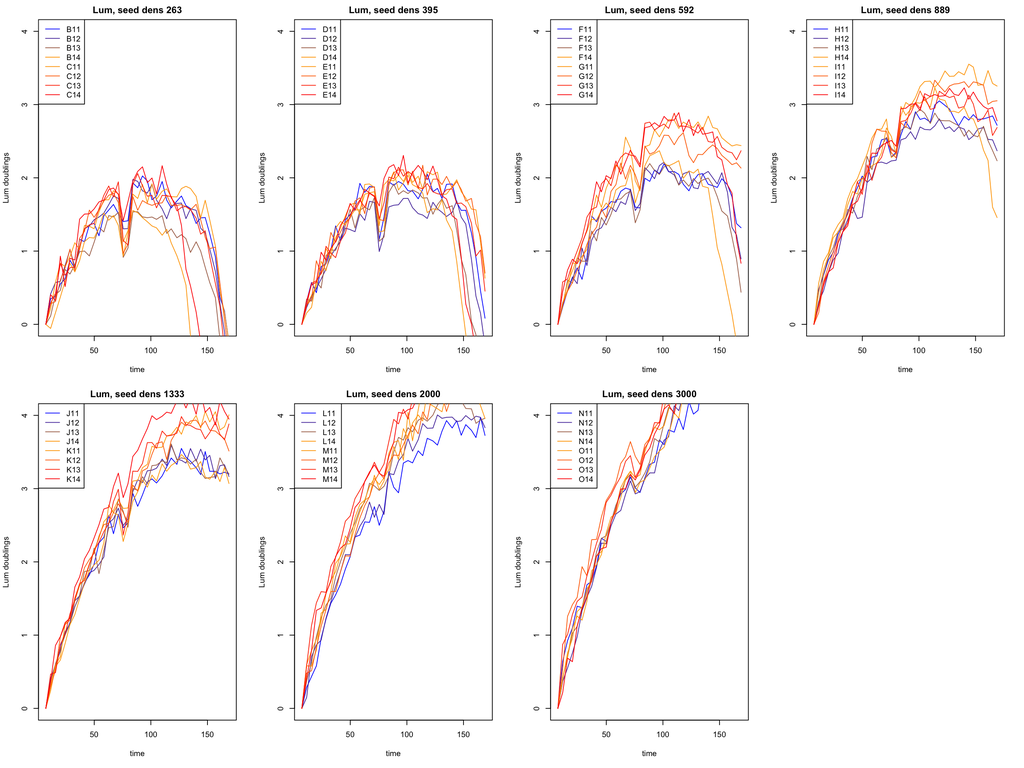

```r
b <- a[a$plate_id != 1,]

par(mfrow=c(2,4))
temp <- lapply(unique(b$drug1), function(drug)
{
    dtp <- b[b$drug1==drug,]
    invisible(do.call(plotGC, append(getGCargs(dat=dtp,
                                               arg.name = c("time", "cell.count", "ids"),
                                               dat.col = c("time", "lum", "uid")),
                                     list(main=paste("Lum, seed dens",drug),
                                          ylim=c(0,4), ylab="Lum doublings"
                                          ))))
})
```

### Replot cell counts for comparison

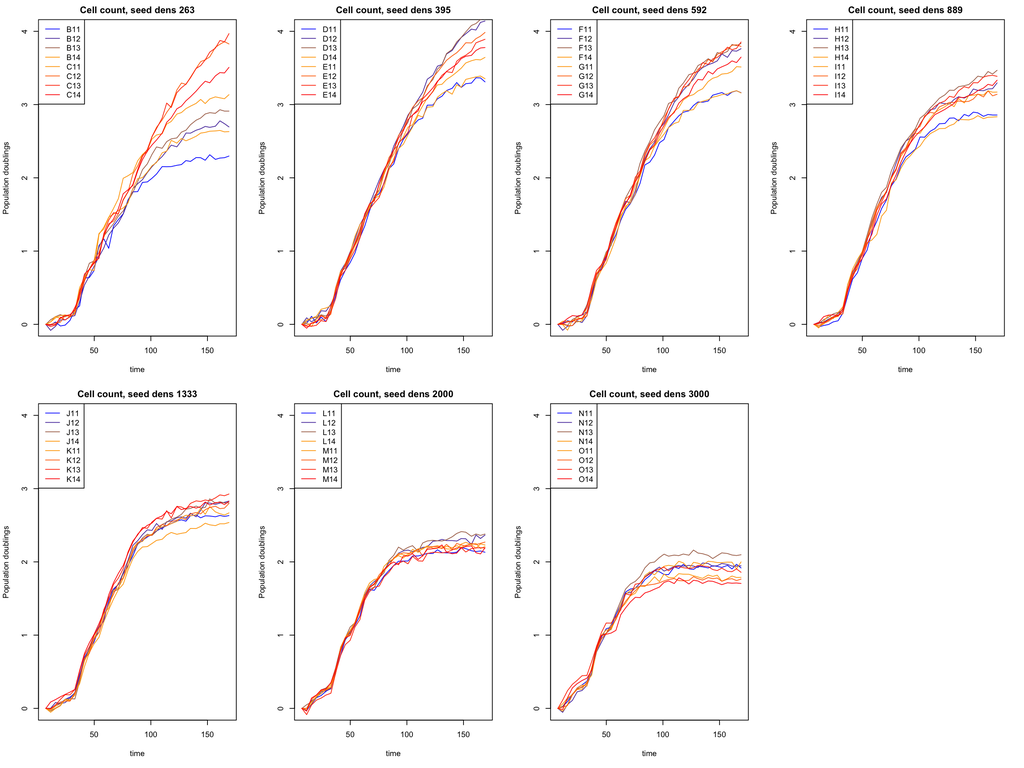

```r
par(mfrow=c(2,4))
temp <- lapply(unique(b$drug1), function(drug)
{
    dtp <- b[b$drug1==drug,]
    invisible(do.call(plotGC, append(getGCargs(dat=dtp),
                                     list(main=paste("Cell count, seed dens",drug),
                                          ylim=c(0,4), ylab="Population doublings"))))
})
```